# Demogr App

## Introduction

The objective of this work is get used of demographic techniques to aboard the dynamic multistate problem in health models where there isn’t data about flow transitions. In general, we talk about a closed population with no memory transition (Markov assumption), with only one change by period.

The matrix of transition rates is the main result. In this case we have $s$ living and a death state.

$$U_{x}^{t} = \left(\begin{array}{cccc}
-\sum_{i=2}^{s}m_{x,1i}^{t}-m_{x,1d}^{t} & m_{x,12}^{t} & \cdots & m_{x,1s}^{t} & m_{x,1d}^{t}\\
m_{x,21}^{t} & \ddots & \cdots & m_{x,2s}^{t} & m_{x,2d}^{t}\\
\vdots & \vdots & \ddots & \vdots & \vdots\\
m_{x,s1}^{t} & \cdots & \cdots & -\sum_{i=1}^{s-1}m_{x,si}^{t}-m_{x,sd}^{t} & m_{x,sd}^{t}\\
0 & 0 & \cdots & \cdots & 0\\
\end{array}\right)$$

For demographic purposes like decrement tables construction, the construction of a matrix of probabilities can be donde with an assumption about the rates under the period risk. Under the constant assumption we would have an exponential relationship $P_{x}^{t,h} = exp(U_{x}^{t}*h)$. Insted, in the linear assumption $P_{x}^{t,h} = [I-U_{x}^{t}*h/2][I+U_{x}^{t}*h/2]^{-1}$

In this way, we can obtain the matrix of probabilities:

$$P_{x}^{t,h} = \left(\begin{array}{cccc}
p_{x,11}^{t,h} & p_{x,12}^{t,h} & \cdots & p_{x,1s}^{t,h} & p_{x,1d}^{t,h}\\
p_{x,21}^{t,h} & \ddots & \cdots & p_{x,2s}^{t,h} & p_{x,2d}^{t,h}\\
\vdots & \vdots & \ddots & \vdots & \vdots\\
p_{x,s1}^{t,h} & \cdots & \cdots & p_{x,ss}^{t,h} & p_{x,sd}^{t,h}\\
0 & 0 & \cdots & \cdots & 1
\end{array}\right)$$

We have n states with n-1 transitions each, characterizing a row (or col, depending the arrangement) stochastic transition matrix. In the case of demographic-health multistate model, we only can observe s-1 states distribution at initial time (dead portion is unobservable), so we typical have a matrix transition with $p_{x,ij}^{t,h}$, meaning the probability that a person aged x at time t make a transition from i to j, during the interval h. We have $s$ living states and one $dead$ state (absorbing state).

$$\left(\begin{array}{c}
N_{x,1}^t\\
N_{x,2}^t\\
\vdots\\
N_{x,s}^t\\
0\\
\end{array}\right)^T
P_{x}^{t,h} =
\left(\begin{array}{c}
N_{x+h,1}^{t+h}\\
N_{x+h,2}^{t+h}\\
\vdots\\
N_{x+h,s}^{t+h}\\
N_{x+h,d}^{t+h}\\
\end{array}\right)^T$$

But it’s known that this assumption is not respected in the vast majority of the diseases, so some overall conditions for its resolution can be added (to the stochastic condition $\sum_{i=1}^{s} p_{x,ij}^{t,h} + p_{x,id}^{t,h} = 1$), which can be classified in:  
* Relationship between magnitudes of probabilities in each age (in general terms $p_{x,ij}^{t,h}>=<p_{x,ko}^{t,h}$ for $i\neq k$ or $j \neq o$)  
* Relationship between ages for the same transition rate (parametric form or just inequalities between values)

Let’s consider the case of “strictly” herachical systems, in which all states are not necessarily reachable from any given state. These are acceptable for many progressive diseases like cancer, diabetes, hypertension, and many others. Here we’ll concentrate in the case of two living states with differential mortality. The diagram of states and its transition matrix are like this:

[interactive chart not shown]

$$U_{x}^{t} = \left(\begin{array}{ccc}
-(m_{x,12}^{t}+m_{x,1d}^{t}) & m_{x,12}^{t} & m_{x,1d}^{t}\\
0 & -m_{x,2d}^{t} & m_{x,2d}^{t}\\
0 & 0 & 0
\end{array}\right)$$

# Data

## Data

The source that we will use is the National Risk Factor Survey from Argentina, which collect data about health perception and risk factors like diabetes, hypertension, cholesterol and many others.

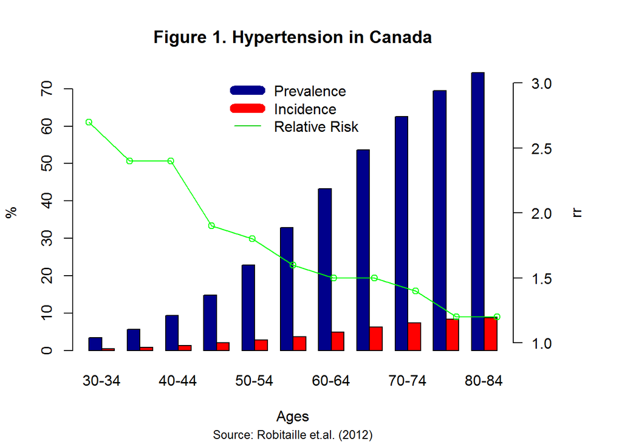

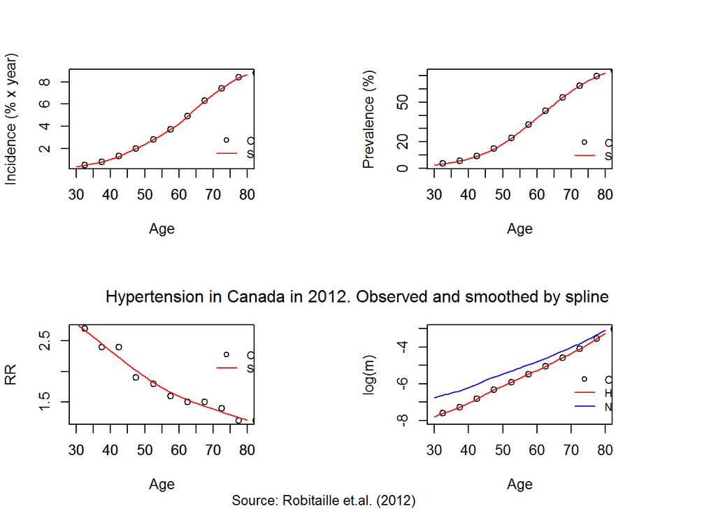

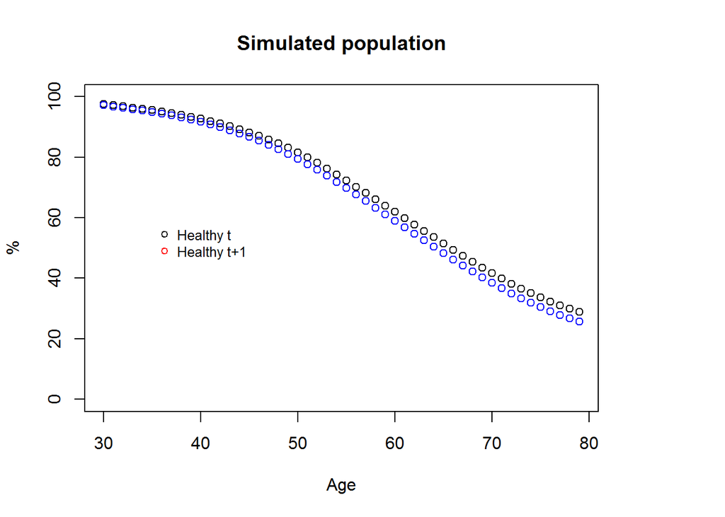

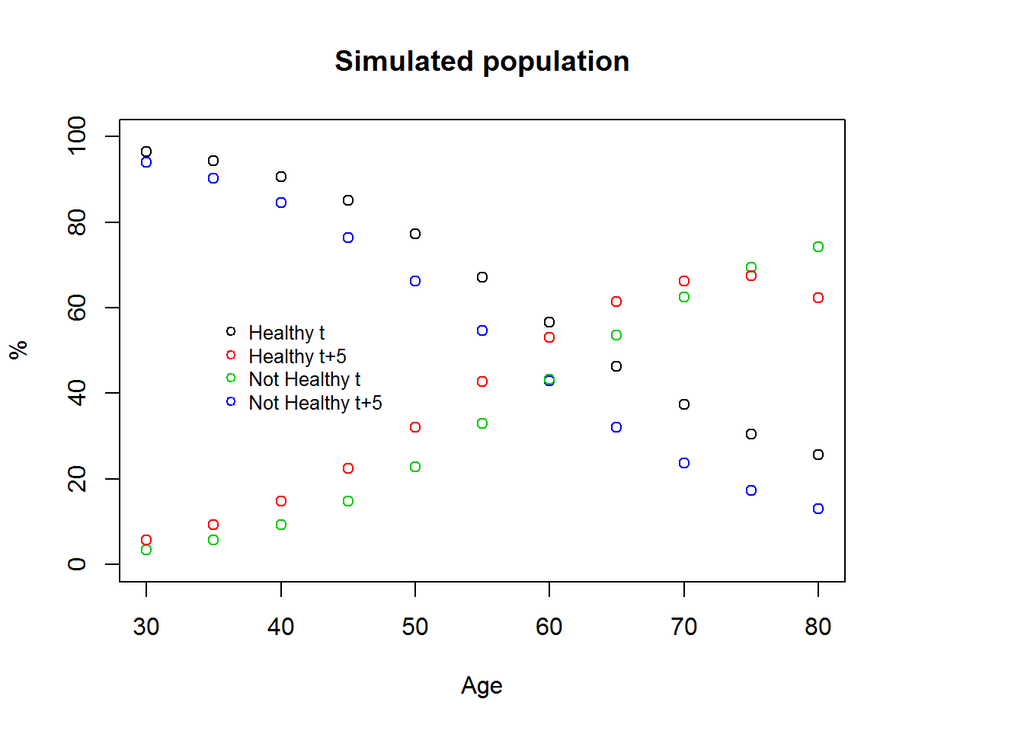

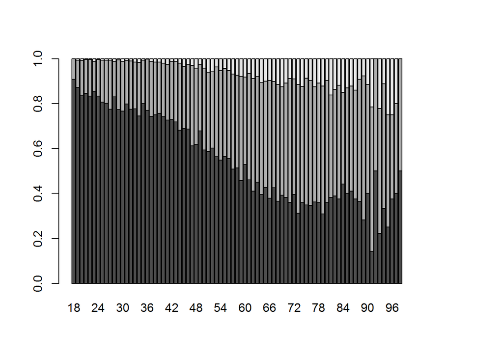